# What I Found Out About My Instagram Ads!

## When am I seeing Instagram ads the most?

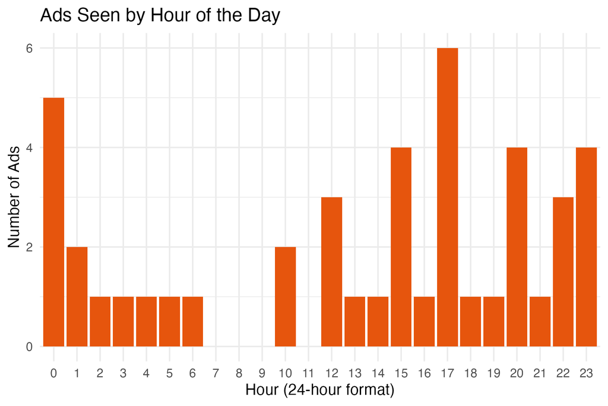

Actually, I noticed that majority of Instagram ads I saw appeared in the afternoon and evening, especially from 3pm to 11pm. This makes sense since these are the times I usually take breaks and usually scroll through Instagram.

But, I also noticed there was a smaller peak around midnight and especially between 12am and 2am. At first, I felt that was surprising, but then I realised that I usually stay up late at night, either studying or just on my phone, so it fits with my routine.

Overall, this chart shows that the ads are showing up when I’m actually using Instagram the most.

## Are these ads from big brands or independent sellers?

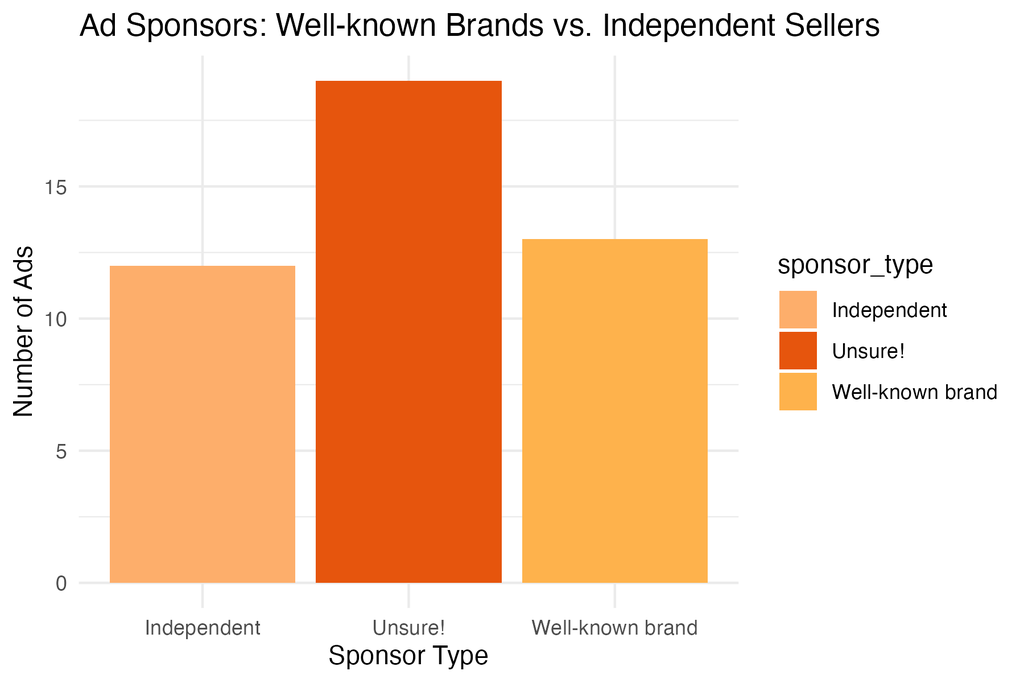

So, when I looked at who was sponsoring the Instagram ads I saw, the most common response was actually “Unsure”. For me, it was like I couldn’t easily tell who the ad was from and like either the account name didn’t stand out, or the post itself didn’t clearly show a brand. This shows that a lot of ads on Instagram aren’t always transparent enough about their sponsors.

Also, I noticed quite a lot of ads were from small businesses or independent sellers. This shows that Instagram is being used a lot by smaller brands, this is because it’s a good way for them to reach users like me without needing a big advertising budget.

## Do these ads match my interests?

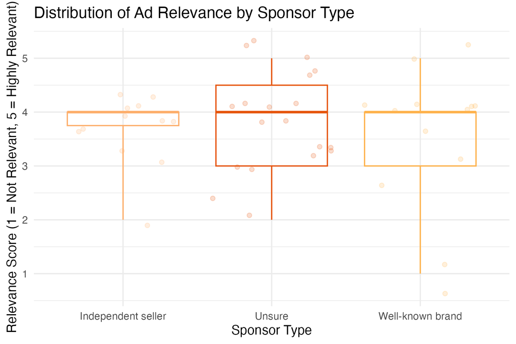

A boxplot showing how relevant I found the ads

I feel like most of the ads I saw was “Somewhat relevant” where, they kind of matched my interests, like things I’ve looked at before or hobbies I enjoy but they didn’t stand out enough to make me click or remember them.

There were a few number of ads were rated “Not relevant”, which shows that they felt random and unrelated to my interests. This also shows that Instagram’s algorithm doesn’t always get it right wherethere are still some ads that miss the mark. Also, only a few ads felt “Very relevant”, like they really knew what I liked.

Therefore, this shows that most of the ads were in the middle, I feel like the ads were like a mix.